# What Factors Contribute Towards World Happiness?

### Contributors: Hanley Yin, Kyle Quain, Krris Vellayapan

## Outline

1. Introduction
2. Data Collection and Data Cleaning
3. Exploratory Data Analysis
4. Hypothesis Testing
5. Communication of Insights Attained

## 1. Introduction

For our data, we used [a dataset](https://www.kaggle.com/datasets/unsdsn/world-happiness) from Kaggle describing World Happiness.

The happiness scores and rankings use data from the Gallup World Poll. The scores are based on answers to the main life evaluation question asked in the poll. This question, known as the Cantril ladder, asks respondents to think of a ladder with the best possible life for them being a 10 and the worst possible life being a 0 and to rate their own current lives on that scale. The scores are from nationally representative samples for the years 2013-2016 and use the Gallup weights to make the estimates representative.

The columns following the happiness score estimate the extent to which each of six factors – economic production, social support, life expectancy, freedom, absence of corruption, and generosity – contribute to making life evaluations higher in each country than they are in Dystopia, a hypothetical country that has values equal to the world’s lowest national averages for each of the six factors. They have no impact on the total score reported for each country, but they do explain why some countries rank higher than others.

Dystopia is an imaginary country that has the world’s least-happy people. The purpose in establishing Dystopia is to have a benchmark against which all countries can be favorably compared (no country performs more poorly than Dystopia) in terms of each of the six key variables, thus allowing each sub-bar to be of positive width. The lowest scores observed for the six key variables, therefore, characterize Dystopia. Since life would be very unpleasant in a country with the world’s lowest incomes, lowest life expectancy, lowest generosity, most corruption, least freedom and least social support, it is referred to as “Dystopia,” in contrast to Utopia.

Using this dataset from Kaggle, our group will analyze these six factors and their relationship to the happiness score and try to determine how strongly these factors can predict a country's happines score. Furthermore, we hope to analyze various ways to visualy display our findings as well as provide the reader with an understanding of how this information is relavent to them.

For the sake of group work, we used Google Collab to collaboratively work on the project, and Google Drive to share the data amongst the three of us

```python
from google.colab import drive
drive.mount('/content/drive')
```

```python
# Necessary imports
import pandas as pd
import matplotlib.pyplot as plt
import seaborn as sns
import numpy as np
import statsmodels.formula.api as sm
!pip install country_converter geopandas
import country_converter as coco
import geopandas as gpd
```

```
     |████████████████████████████████| 53 kB 1.6 MB/s
     |████████████████████████████████| 1.1 MB 7.7 MB/s
     |████████████████████████████████| 16.6 MB 41.8 MB/s
     |████████████████████████████████| 7.8 MB 63.8 MB/s
```

## 2. Data Collection and Data Cleaning

The dataset we used was actually comprised of 5 smaller datasets, which included data from 2015, 2016, 2017, 2018, and 2019. A small nuisance arises from the fact that the columns are not standardized between all five years. As such, some minor data cleaning is necessary, which involved renaming some columns, dropping others, and converting column datatypes to the appropriate type. Other than that, we were able to nicely merge all five years worth of data into a singular dataframe without much headache.

To elaborate on the columns we dropped, our group wanted to focus on the six factors that contrinbuted to the happiness score (Economy, Family, Life Expectancy, Freedom, Trust, & Generosity) as well as the Dystopia Residual, the positive residual from each country compared to Dystopia, as mentioned earlier. So, our group decided to drop all other columns that either were not present in the other datasets or were not relevant to our goal (such as dropping the column Region from the 2015 and 2016 dataset since it was not present in the others and was not relevant to a specific country's Happiness Score).

```python
# Importing dataframes for each year
colnames = ['Country', 'Region', 'Happiness Rank', 'Happiness Score', 'Standard Error', 'Economy', 'Family', 'Life Expectancy', 'Freedom', 'Trust', 'Generosity', 'Dystopia Residual']
df_2015 = pd.read_csv("/content/drive/MyDrive/CMSC320 Final Project/2015.csv", names=colnames, header=None)
df_2015 = df_2015.drop(['Region', 'Standard Error'], axis=1).drop(index=0) # Dropping Region as well as Standard Error

colnames = ['Country', 'Region', 'Happiness Rank', 'Happiness Score', 'Lower Confidence Interval', 'Upper Confidence Interval', 'Economy', 'Family', 'Life Expectancy', 'Freedom', 'Trust', 'Generosity','Dystopia Residual']
df_2016 = pd.read_csv("/content/drive/MyDrive/CMSC320 Final Project/2016.csv", names=colnames, header=None)
df_2016 = df_2016.drop(['Region', 'Lower Confidence Interval', 'Upper Confidence Interval'], axis=1).drop(index=0) # Dropping Region, Lower & Upper Confidence Interval

colnames = ['Country', 'Happiness Rank', 'Happiness Score', 'Whisker.high', 'Whisker.low', 'Economy', 'Family', 'Life Expectancy', 'Freedom', 'Generosity', 'Trust', 'Dystopia Residual']
df_2017 = pd.read_csv("/content/drive/MyDrive/CMSC320 Final Project/2017.csv", names=colnames, header=None)
df_2017 = df_2017.drop(['Whisker.high', 'Whisker.low'], axis=1).drop(index=0) # Dropping Whisker high and low

colnames = ['Happiness Rank', 'Country', 'Happiness Score', 'Economy', 'Family', 'Life Expectancy', 'Freedom', 'Generosity', 'Trust']
df_2018 = pd.read_csv("/content/drive/MyDrive/CMSC320 Final Project/2018.csv", names=colnames, header=None)
df_2018 = df_2018.drop(index=0)

colnames = ['Happiness Rank', 'Country', 'Happiness Score', 'Economy', 'Family', 'Life Expectancy', 'Freedom', 'Generosity', 'Trust']
df_2019 = pd.read_csv("/content/drive/MyDrive/CMSC320 Final Project/2019.csv", names=colnames, header=None)
df_2019 = df_2019.drop(index=0)

# Concatenating all the years together into one large dataframe
dataframes = [df_2015, df_2016, df_2017, df_2018, df_2019]

df = pd.concat(dataframes, keys=['2015', '2016', '2017', '2018', '2019']).reset_index().rename(columns={'level_0': 'Year'}).drop(['level_1', 'Happiness Rank'], axis=1)
df = df.astype({'Year': 'int32', 'Country': 'string', 'Happiness Score': 'float', 'Economy': 'float', 'Family': 'float', 'Life Expectancy': 'float', 'Freedom': 'float', 'Trust': 'float', 'Generosity': 'float', 'Dystopia Residual': 'float'})

df.head()

display(df)
```

|  | Year | Country | Happiness Score | Economy | Family | Life Expectancy | Freedom | Trust | Generosity | Dystopia Residual |
| --- | --- | --- | --- | --- | --- | --- | --- | --- | --- | --- |
| 0 | 2015 | Switzerland | 7.587 | 1.39651 | 1.34951 | 0.94143 | 0.66557 | 0.41978 | 0.29678 | 2.51738 |
| 1 | 2015 | Iceland | 7.561 | 1.30232 | 1.40223 | 0.94784 | 0.62877 | 0.14145 | 0.43630 | 2.70201 |
| 2 | 2015 | Denmark | 7.527 | 1.32548 | 1.36058 | 0.87464 | 0.64938 | 0.48357 | 0.34139 | 2.49204 |
| 3 | 2015 | Norway | 7.522 | 1.45900 | 1.33095 | 0.88521 | 0.66973 | 0.36503 | 0.34699 | 2.46531 |
| 4 | 2015 | Canada | 7.427 | 1.32629 | 1.32261 | 0.90563 | 0.63297 | 0.32957 | 0.45811 | 2.45176 |
| ... | ... | ... | ... | ... | ... | ... | ... | ... | ... | ... |
| 777 | 2019 | Rwanda | 3.334 | 0.35900 | 0.71100 | 0.61400 | 0.55500 | 0.41100 | 0.21700 | NaN |
| 778 | 2019 | Tanzania | 3.231 | 0.47600 | 0.88500 | 0.49900 | 0.41700 | 0.14700 | 0.27600 | NaN |
| 779 | 2019 | Afghanistan | 3.203 | 0.35000 | 0.51700 | 0.36100 | 0.00000 | 0.02500 | 0.15800 | NaN |
| 780 | 2019 | Central African Republic | 3.083 | 0.02600 | 0.00000 | 0.10500 | 0.22500 | 0.03500 | 0.23500 | NaN |
| 781 | 2019 | South Sudan | 2.853 | 0.30600 | 0.57500 | 0.29500 | 0.01000 | 0.09100 | 0.20200 | NaN |

782 rows × 10 columns

## 3. Exploratory Data Analysis

Before we analyze the best countries and their scores, we need to frist explor the data. First, lets take a brief look at some of the attributes, to get a better idea of their distributions. We do this by simply plotting some basic histograms of some relevant attributes, which include 'Happiness Score', 'Economy', 'Family', 'Life Expectancy', 'Freedom', 'Trust', 'Generosity', and 'Dystopia Residual', as well as computing the mean values of each.

```
Year                 2016.993606
Happiness Score         5.379018
Economy                 0.916047
Family                  1.078392
Life Expectancy         0.612416
Freedom                 0.411091
Trust                   0.125436
Generosity              0.218576
Dystopia Residual       2.092717
dtype: float64
```

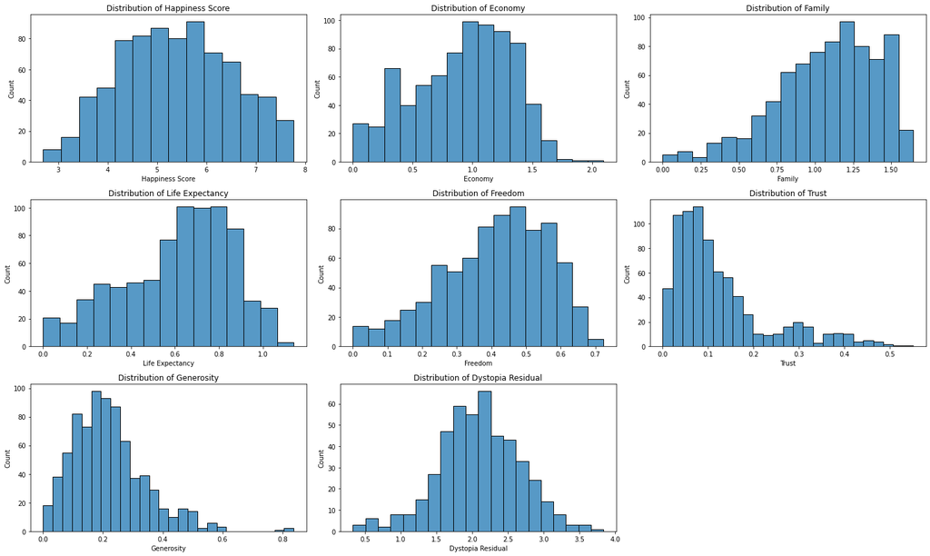

```python
# Creating Histograms
fig, axes = plt.subplots(nrows=3, ncols=3, figsize=(20,12))
fig.delaxes(axes[2][2])
attributes = ['Happiness Score', 'Economy', 'Family', 'Life Expectancy', 'Freedom', 'Trust', 'Generosity', 'Dystopia Residual']

# Print the means for each numeric variable
print(df.mean(numeric_only = True))

# Create a Histogram based on each attribute
for (attr, ax) in zip(attributes, axes.flatten()):
    sns.histplot(data=df, x=attr, ax = ax).set(title="Distribution of " + attr)

fig.tight_layout()

plt.show()
```

As expected, much of the data was unimodal and appeared roughly normal. However, some of the factors were skewed in either direction.

1. The Happiness Score appeared to be approximately normally distributed. This should be expected that the Happiness Score, calculated based off all the other countries in comparison to Dystopia, is normally distributed.
2. The factor Economy and the Dystopia Residual were the only other two that were approximately normal.
3. Trust and Generosity were heavily skewed right, with relatively low values. This means that low trust in the government and a low ranking for generosity did not play a very big role in the calculation of happiness because the majority of countries has a low trust or generosity score respecitvely so the extreme values would have more weight in the score calcuation.
4. Conversely, Family, Life Expectancy, and Freedom were skewed left with a majority of the datapoints taking on high values. This skew would indicate that low values, being more extreme and less common, would most likely have a higher weight in calculating the Happiness Score.

For the distributions that were skewed, the distributions that were skewed left would indiciate that those low values have more weight in calculating the Happiness Score, with the converse for skewed right distributions implying high values had more weight respectively. To be specific, for the skewed left distributions such as Life Expectancy, low values for Life Expectancy, which would be expected to indicate a correlation with low happiness for a country, have a stronger weight in calculating the Happiness Score. And, for the skewed right factors such as Trust and Generosity, where higher Trust and higher Generosity values would indiciate a happier country, these high values should indicate a correlation with a higher Happiness Score, but we will analyze the strength of these correlations after exploring the data some more.

Lets see how much happiness changes per year, if it does at all:

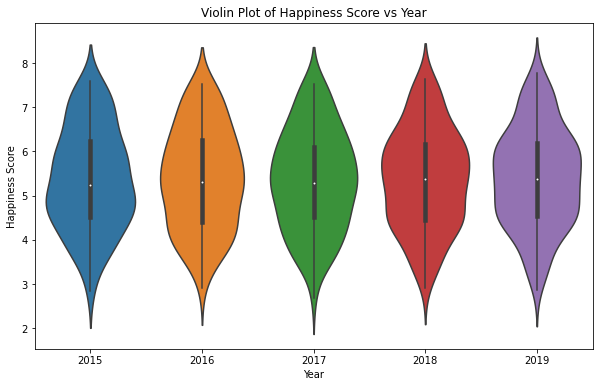

```python
# Create a violin plot
plt.figure(figsize = (10, 6))
sns.violinplot(y='Happiness Score', x='Year', data=df, estimator='mean')
plt.title('Violin Plot of Happiness Score vs Year')
plt.show()
```

Over the course of these 5 years, it doesn't appear like global average of happiness score has changes much, which means it might not make sense to analyze how much happiness changes over time. (Or more realistically, we would need data on a much longer scale such as decades instead of years, as there is not much that can really be done in only five years to affect a statistically significant difference in happiness). A worthy note to add is that the bulk of data for Happiness Score does seem to shift upwards immediately from 2015 to 2016 and then remains constant until 2019. However, the extremes seem to thin out from 2015 as well.

Now, lets compare each of our attributes agaisnt the variable of interest, happiness score by drawing some scatter plots.

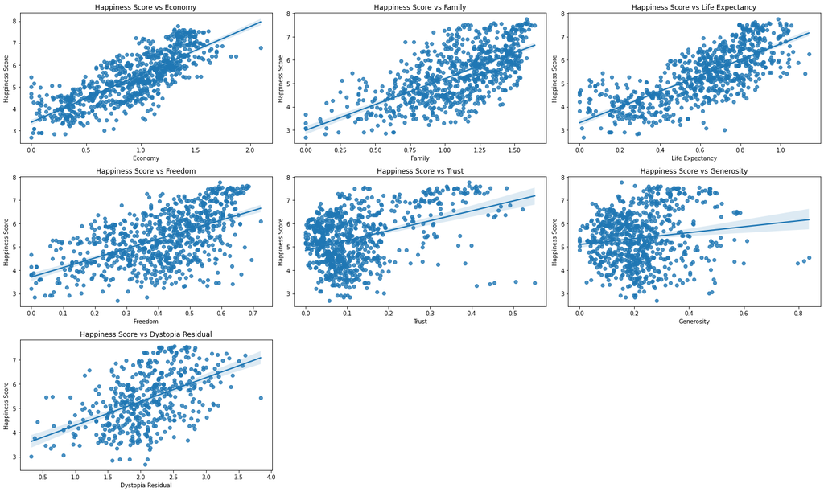

```python
# Plotting the scattersplots of Happiness Score against each factor and Dystopia Residual
fig, axes = plt.subplots(nrows=3, ncols=3, figsize=(20,12))
fig.delaxes(axes[2][2])
fig.delaxes(axes[2][1])
attributes = ['Economy', 'Family', 'Life Expectancy', 'Freedom', 'Trust', 'Generosity', 'Dystopia Residual']

# Plot each scatterplot individually
for (attr, ax) in zip(attributes, axes.flatten()):
    sns.regplot(data=df, x=attr, y = "Happiness Score",  ax = ax).set(title="Happiness Score vs " + attr)

fig.tight_layout()

plt.show()
```

Before we analyze the correlation of these regression lines, we can already see some trends from the data. From these graphs, it appears as though Economy, Family, and Life expectancy play a big role in how happy a country is. Freedom also tend to have a general positive correlation that seems moderately strong. However, Trust and Generosity appear to not be very strongly correlated and are very scattered.

## 4. Hypothesis Testing

Lets see what statistics have to say about it: We will create a correlation matrix using Pearson Correlation Matrix, one which will display correlation as a continuous heatmap and one which bins correlations into discrete bins.

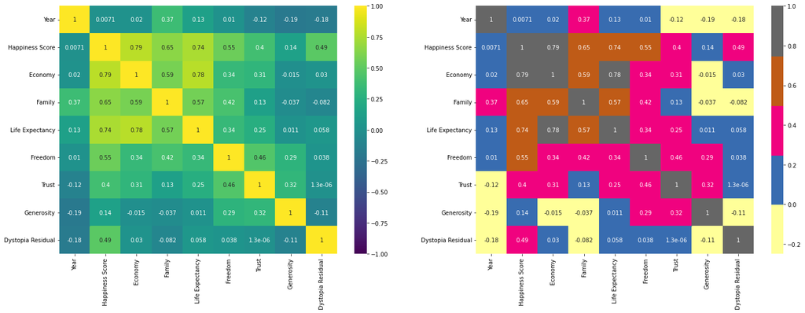

```python
# Correlation Matrix
cormatrix= df.corr(method='pearson')
fig, ax = plt.subplots(ncols=2,figsize=(24, 8))

# This first heatmap shows the correlation matrix with a scale from cold to warm colors representing low correlation to high correlation respectively
sns.heatmap(cormatrix, vmin=-1, vmax=1, ax=ax[0], center=0, cmap="viridis", annot=True)

# This second heatmap displays the same information as the first heatmap but with non-blending colors to show distinct groups
sns.heatmap(cormatrix, vmin=-.25, vmax=1, ax=ax[1], center=0, cmap="Accent", annot=True)
```

As expected, values highly correlated with Happiness Score were Economy, Family, and Life Expectancy, with other attributes taking on lower values. Economy, Family, and Life Expectancy all had a Pearson Correlation of at least 0.65 which is relatively high. This means that these three factors have a linera regression model that may be a good indicator at predicting scores based off these values within the same range. To elaborate, since all three regression models depict a positive correlation, the higher the factor, the higher the Happiness Score should be. As for the values that were not highly correlated - Freedom, Trust, and Generosity - these values did not have a high correlation as all three were less than 0.6 with Trust and Generosity having a Pearson correlation of 0.4 or less. This means that their regressino models may not be very accurate in predicting the Happiness Score within the given range. So, this means that while the linear regression models all depict a positive correlation, their models may not be very accurate in proving that high values for these factors indiciate a high Happiness Score.

Now that we have found the Pearson correlation matrix, we should determine via hypothesis testing how accurate these linear regression models are at predicting the Happiness Score, again.

```python
from statsmodels.formula.api import ols

result1 = ols(formula = "Q('Happiness Score') ~ Economy", data = df).fit()
print(result1.summary())
```

```
                             OLS Regression Results
================================================================================
Dep. Variable:     Q('Happiness Score')   R-squared:                       0.623
Model:                              OLS   Adj. R-squared:                  0.622
Method:                   Least Squares   F-statistic:                     1289.
Date:                  Sat, 17 Dec 2022   Prob (F-statistic):          2.21e-167
Time:                          04:51:48   Log-Likelihood:                -821.53
No. Observations:                   782   AIC:                             1647.
Df Residuals:                       780   BIC:                             1656.
Df Model:                             1
Covariance Type:              nonrobust
==============================================================================
                 coef    std err          t      P>|t|      [0.025      0.975]
------------------------------------------------------------------------------
Intercept      3.3778      0.061     55.373      0.000       3.258       3.498
Economy        2.1846      0.061     35.900      0.000       2.065       2.304
==============================================================================
Omnibus:                        3.493   Durbin-Watson:                   1.243
Prob(Omnibus):                  0.174   Jarque-Bera (JB):                2.858
Skew:                          -0.025   Prob(JB):                        0.240
Kurtosis:                       2.708   Cond. No.                         4.71
==============================================================================

Notes:
[1] Standard Errors assume that the covariance matrix of the errors is correctly specified.
```

The code above runs a hypothesis test to test whether or not there is a relationship between the Happiness Score and Economy Variables. We ran the ols fit function on the model to print the final summary of the p-value. We had a null hypothesis of there being no relationship between the Happiness Score and Economy variables. Since after running the hypothesis test we had a p-value of 0.000 we were able to reject the null hypothesis and conclude that there is a relationship between the Happiness Score and Economy variables. Another statistic we took note of in this summary was the r-squared value. Since we had a r-squared value of 0.623, we could say that our model was reliable and could be used so this helped support the conclusio of there being a relationship between the two variables.

```python
result2 = ols(formula = "Q('Happiness Score') ~ Family", data = df).fit()
print(result2.summary())
```

```
                             OLS Regression Results
================================================================================
Dep. Variable:     Q('Happiness Score')   R-squared:                       0.421
Model:                              OLS   Adj. R-squared:                  0.420
Method:                   Least Squares   F-statistic:                     567.0
Date:                  Sat, 17 Dec 2022   Prob (F-statistic):           1.27e-94
Time:                          04:51:48   Log-Likelihood:                -989.30
No. Observations:                   782   AIC:                             1983.
Df Residuals:                       780   BIC:                             1992.
Df Model:                             1
Covariance Type:              nonrobust
==============================================================================
                 coef    std err          t      P>|t|      [0.025      0.975]
------------------------------------------------------------------------------
Intercept      2.9853      0.105     28.403      0.000       2.779       3.192
Family         2.2197      0.093     23.812      0.000       2.037       2.403
==============================================================================
Omnibus:                        9.022   Durbin-Watson:                   0.512
Prob(Omnibus):                  0.011   Jarque-Bera (JB):                6.445
Skew:                           0.092   Prob(JB):                       0.0398
Kurtosis:                       2.595   Cond. No.                         6.75
==============================================================================

Notes:
[1] Standard Errors assume that the covariance matrix of the errors is correctly specified.
```

The code above runs a hypothesis test to test whether or not there is a relationship between the Happiness Score and Family Variables. We ran the ols fit function on the model to print the final summary of the p-value. We had a null hypothesis of there being no relationship between the Happiness Score and Family variables. Since after running the hypothesis test we had a p-value of 0.000 we were able to reject the null hypothesis and conclude that there is a relationship between the Happiness Score and Family variables. Another statistic we took note of in this summary was the r-squared value. Since we had a r-squared value of 0.421, we could say that even though we were able to reject the null hypothesis, the somewhat high r-squared value meant that the model is somewhat reliable, and should be used with caution.

```python
result3 = ols(formula = "Q('Happiness Score') ~ Q('Life Expectancy')", data = df).fit()
print(result3.summary())
```

```
                             OLS Regression Results
================================================================================
Dep. Variable:     Q('Happiness Score')   R-squared:                       0.551
Model:                              OLS   Adj. R-squared:                  0.551
Method:                   Least Squares   F-statistic:                     958.1
Date:                  Sat, 17 Dec 2022   Prob (F-statistic):          7.41e-138
Time:                          04:51:48   Log-Likelihood:                -889.63
No. Observations:                   782   AIC:                             1783.
Df Residuals:                       780   BIC:                             1793.
Df Model:                             1
Covariance Type:              nonrobust
========================================================================================
                           coef    std err          t      P>|t|      [0.025      0.975]
----------------------------------------------------------------------------------------
Intercept                3.3145      0.072     46.056      0.000       3.173       3.456
Q('Life Expectancy')     3.3712      0.109     30.954      0.000       3.157       3.585
==============================================================================
Omnibus:                       12.782   Durbin-Watson:                   0.953
Prob(Omnibus):                  0.002   Jarque-Bera (JB):                8.911
Skew:                          -0.135   Prob(JB):                       0.0116
Kurtosis:                       2.552   Cond. No.                         5.61
==============================================================================

Notes:
[1] Standard Errors assume that the covariance matrix of the errors is correctly specified.
```

```python
result4 = ols(formula = "Q('Happiness Score') ~ Freedom", data = df).fit()
print(result4.summary())
```

```
                             OLS Regression Results
================================================================================
Dep. Variable:     Q('Happiness Score')   R-squared:                       0.304
Model:                              OLS   Adj. R-squared:                  0.303
Method:                   Least Squares   F-statistic:                     340.5
Date:                  Sat, 17 Dec 2022   Prob (F-statistic):           2.28e-63
Time:                          04:51:48   Log-Likelihood:                -1061.3
No. Observations:                   782   AIC:                             2127.
Df Residuals:                       780   BIC:                             2136.
Df Model:                             1
Covariance Type:              nonrobust
==============================================================================
                 coef    std err          t      P>|t|      [0.025      0.975]
------------------------------------------------------------------------------
Intercept      3.7078      0.097     38.374      0.000       3.518       3.897
Freedom        4.0654      0.220     18.453      0.000       3.633       4.498
==============================================================================
Omnibus:                       27.000   Durbin-Watson:                   0.657
Prob(Omnibus):                  0.000   Jarque-Bera (JB):               24.212
Skew:                          -0.371   Prob(JB):                     5.53e-06
Kurtosis:                       2.561   Cond. No.                         7.67
==============================================================================

Notes:
[1] Standard Errors assume that the covariance matrix of the errors is correctly specified.
```

```python
result5 = ols(formula = "Q('Happiness Score') ~ Trust", data = df).fit()
print(result5.summary())
```

```
                             OLS Regression Results
================================================================================
Dep. Variable:     Q('Happiness Score')   R-squared:                       0.159
Model:                              OLS   Adj. R-squared:                  0.158
Method:                   Least Squares   F-statistic:                     147.0
Date:                  Sat, 17 Dec 2022   Prob (F-statistic):           4.11e-31
Time:                          04:51:48   Log-Likelihood:                -1133.6
No. Observations:                   781   AIC:                             2271.
Df Residuals:                       779   BIC:                             2281.
Df Model:                             1
Covariance Type:              nonrobust
==============================================================================
                 coef    std err          t      P>|t|      [0.025      0.975]
------------------------------------------------------------------------------
Intercept      4.8449      0.057     84.368      0.000       4.732       4.958
Trust          4.2436      0.350     12.124      0.000       3.557       4.931
==============================================================================
Omnibus:                       23.762   Durbin-Watson:                   0.306
Prob(Omnibus):                  0.000   Jarque-Bera (JB):               24.496
Skew:                          -0.411   Prob(JB):                     4.79e-06
Kurtosis:                       2.723   Cond. No.                         9.61
==============================================================================

Notes:
[1] Standard Errors assume that the covariance matrix of the errors is correctly specified.
```

```python
result6 = ols(formula = "Q('Happiness Score') ~ Generosity", data = df).fit()
print(result6.summary())
```

```
                             OLS Regression Results
================================================================================
Dep. Variable:     Q('Happiness Score')   R-squared:                       0.019
Model:                              OLS   Adj. R-squared:                  0.018
Method:                   Least Squares   F-statistic:                     15.05
Date:                  Sat, 17 Dec 2022   Prob (F-statistic):           0.000114
Time:                          04:51:48   Log-Likelihood:                -1195.4
No. Observations:                   782   AIC:                             2395.
Df Residuals:                       780   BIC:                             2404.
Df Model:                             1
Covariance Type:              nonrobust
==============================================================================
                 coef    std err          t      P>|t|      [0.025      0.975]
------------------------------------------------------------------------------
Intercept      5.1018      0.082     62.320      0.000       4.941       5.263
Generosity     1.2681      0.327      3.879      0.000       0.626       1.910
==============================================================================
Omnibus:                       66.525   Durbin-Watson:                   0.126
Prob(Omnibus):                  0.000   Jarque-Bera (JB):               22.447
Skew:                          -0.092   Prob(JB):                     1.34e-05
Kurtosis:                       2.191   Cond. No.                         8.58
==============================================================================

Notes:
[1] Standard Errors assume that the covariance matrix of the errors is correctly specified.
```

## 5. Communication of Insights Attained

Now that we have an idea what factors are a better indicator of a higher Happiness Score, let's examine some specific countries to see how their Happiness Scores have been calcuated.

Lets see how the data looks on a map: We'll have to average out the happiness scores for each country across all 5 years. To do this, we'll first group the data by Country, and take the mean of the remaining columns.

To actually plot data by country, we'll make use of the Geopandas Library. In particular, we'll join the "naturalearth_lowres" Geo-Dataframe with our merged dataframe on country code, which will allow us to plot the Happiness Score from our merged dataframe using the location column. In order to get country codes, we also used an external library `country_converter` to convert country names to the ISO-3 Standard country codes.

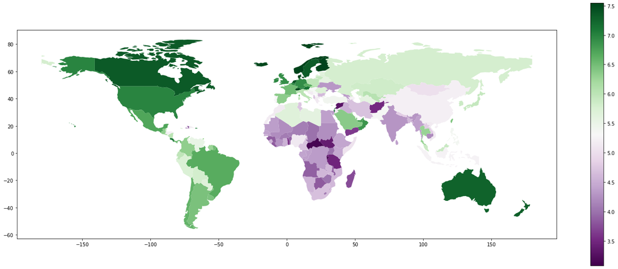

```python
# Grouping all 5 rows from each country together into a single row by averaging out values
merged_df = df.groupby("Country").mean().reset_index()
# Generating country codes
merged_df['CODE']= coco.convert(names=merged_df['Country'], to='ISO3', not_found=None)

# Loading in the world GeoDataFrame
world = gpd.read_file(gpd.datasets.get_path("naturalearth_lowres"))
world.columns=['pop_est', 'continent', 'name', 'CODE', 'gdp_md_est', 'geometry']

# Doing a join on the two prior dataframes to get all necessary information into a singluar DataFrame
merge=pd.merge(world,merged_df, left_on = 'CODE', right_on = 'CODE', how = 'left')
merge.plot(column = 'Happiness Score', cmap = 'PRGn', figsize=(25, 10), legend = True)
```

This graph plots countries with around average happiness of around 5.379018 with gray colors, countries with below average happiness with increasingly intense purple values, and countries with above average happiness with increasingly intense green values.

Here, we can see that much of Eastern Asia and Southeastern Asia is pretty neutrally happy, whereas much of the America's and Europe are happier than the rest of the world. Most notably, most of Africa and Southern Asia appears in shades of purple, which may be also highly correlated to the developed vs. undeveloped regions of the world.

Finally, let's create the average scores for each country over the five years to be able to see which countries specifically had the highest and lowest scores as well as their average scores for the six factors.

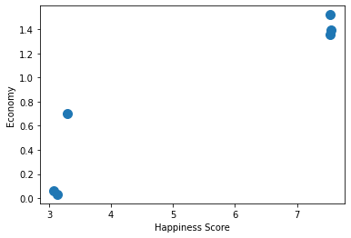

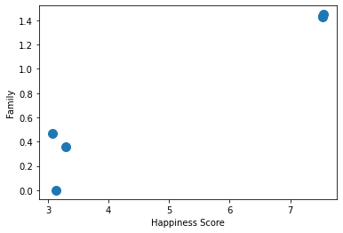

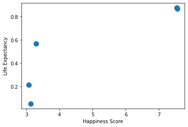

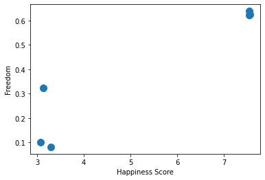

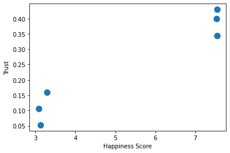

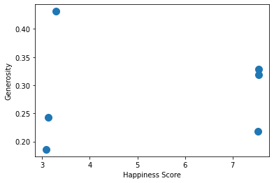

```python
# Creating a new dataframe based off the averages
groups = df.groupby('Country')
happiness_score = []
economy = []
family = []
life_expectancy = []
freedom = []
trust = []
generosity = []
coun = []

# For each country, find the average across the five years and append to the new dataframe
for country, group in groups:
  mask = df["Country"].apply(lambda x: x == country)
  country_data = df[mask]
  coun.append(country)
  happiness_score.append(country_data["Happiness Score"].mean())
  economy.append(country_data["Economy"].mean())
  family.append(country_data["Family"].mean())
  life_expectancy.append(country_data["Life Expectancy"].mean())
  freedom.append(country_data["Freedom"].mean())
  trust.append(country_data["Trust"].mean())
  generosity.append(country_data["Generosity"].mean())
  avg = pd.DataFrame()
  avg['Country'] = coun
  avg['Happiness Score'] = happiness_score
  avg['Economy'] = economy
  avg['Family'] = family
  avg['Life Expectancy'] = life_expectancy
  avg['Freedom'] = freedom
  avg['Trust'] = trust
  avg['Generosity'] = generosity

# Now plot the top three and bottom three countries based off Happiness Score
# and the six factors to see how accurate they are at predicting the score
avg = avg.sort_values(by=['Happiness Score'], ascending=False)
largest = avg.nlargest(3,['Happiness Score'])
smallest = avg.nsmallest(3,['Happiness Score'])
frames = [largest,smallest]
result = pd.concat(frames)
result.plot.scatter(x = 'Happiness Score', y = 'Economy', s = 100)
result.plot.scatter(x = 'Happiness Score', y = 'Family', s = 100)
result.plot.scatter(x = 'Happiness Score', y = 'Life Expectancy', s = 100)
result.plot.scatter(x = 'Happiness Score', y = 'Freedom', s = 100)
result.plot.scatter(x = 'Happiness Score', y = 'Trust', s = 100)
result.plot.scatter(x = 'Happiness Score', y = 'Generosity', s = 100)
```

Supporting our earlier conclusions, we can see the some of the factors have an easy to see correlation between high Happiness Scores and one of the six factors. For example, we can see that for Economy, Family, Freedom, and Trust factors that the bottom three all have relatively low values for their factors respectively. Life Expectancy is relatively correlated between high and low Happiness Scores but the variance among the lowest three countries are pretty high. Lastly, as discovered earlier, the values for Generosity seem to not be strongly correlated with the Happiness Score.

As the reader, countries and individuals should understand the importance of a stable economy, emphasis on support for family and social situations, healthcare boosting life expectancy, and freedom and people's rights and how they all increase the happiness of the general population.